# Regression Models - Quiz 4

Fenton Taylor

September 7, 2016

```r
library(MASS)
library(dplyr)
```

## Question 1

Consider the space shuttle data ?shuttle in the MASS library. Consider modeling the use of the autolander as the outcome (variable name use). Fit a logistic regression model with autolander (variable auto) use (labeled as “auto” 1) versus not (0) as predicted by wind sign (variable wind). Give the estimated odds ratio for autolander use comparing head winds, labeled as “head” in the variable headwind (numerator) to tail winds (denominator).

```r
data("shuttle")
shuttle <- mutate(shuttle, use = relevel(use, ref="noauto"))
shuttle$use.bin <- as.integer(shuttle$use) - 1
mdl <- glm(use.bin ~ wind - 1, family = "binomial", data = shuttle)
summary(mdl)
```

```
##
## Call:
## glm(formula = use.bin ~ wind - 1, family = "binomial", data = shuttle)
##
## Deviance Residuals:
##    Min      1Q  Median      3Q     Max
##  -1.30   -1.29    1.06    1.07    1.07
##
## Coefficients:
##          Estimate Std. Error z value Pr(>|z|)
## windhead    0.251      0.178    1.41     0.16
## windtail    0.283      0.179    1.59     0.11
##
## (Dispersion parameter for binomial family taken to be 1)
##
##     Null deviance: 354.89  on 256  degrees of freedom
## Residual deviance: 350.35  on 254  degrees of freedom
## AIC: 354.3
##
## Number of Fisher Scoring iterations: 4
```

```r
exp(coef(mdl))
```

```
## windhead windtail
##     1.29     1.33
```

```r
exp(coef(mdl)[[1]])/exp(coef(mdl)[[2]])
```

```
## [1] 0.969
```

#### Answer 1:

The odds ratio is 0.969.

## Question 2

Consider the previous problem. Give the estimated odds ratio for autolander use comparing head winds (numerator) to tail winds (denominator) adjusting for wind strength from the variable magn.

```r
mdl2 <- glm(use.bin ~ wind + magn - 1, family = "binomial", data = shuttle)
summary(mdl2)
```

```
##
## Call:
## glm(formula = use.bin ~ wind + magn - 1, family = "binomial",
##     data = shuttle)
##
## Deviance Residuals:
##    Min      1Q  Median      3Q     Max
##  -1.35   -1.32    1.01    1.04    1.18
##
## Coefficients:
##             Estimate Std. Error z value Pr(>|z|)
## windhead    3.64e-01   2.84e-01    1.28     0.20
## windtail    3.96e-01   2.84e-01    1.39     0.16
## magnMedium -1.01e-15   3.60e-01    0.00     1.00
## magnOut    -3.80e-01   3.57e-01   -1.06     0.29
## magnStrong -6.44e-02   3.59e-01   -0.18     0.86
##
## (Dispersion parameter for binomial family taken to be 1)
##
##     Null deviance: 354.89  on 256  degrees of freedom
## Residual deviance: 348.78  on 251  degrees of freedom
## AIC: 358.8
##
## Number of Fisher Scoring iterations: 4
```

```r
exp(coef(mdl2))
```

```
##   windhead   windtail magnMedium    magnOut magnStrong
##      1.438      1.485      1.000      0.684      0.938
```

```r
exp(coef(mdl2))[[1]]/exp(coef(mdl2))[[2]]
```

```
## [1] 0.968
```

## Question 3

If you fit a logistic regression model to a binary variable, for example use of the autolander, then fit a logistic regression model for one minus the outcome (not using the autolander) what happens to the coefficients?

```r
mdl3 <- glm(1- use.bin ~ wind - 1, family = "binomial", data = shuttle)
summary(mdl)$coef
```

```
##          Estimate Std. Error z value Pr(>|z|)
## windhead    0.251      0.178    1.41    0.158
## windtail    0.283      0.179    1.59    0.113
```

```r
summary(mdl3)$coef
```

```
##          Estimate Std. Error z value Pr(>|z|)
## windhead   -0.251      0.178   -1.41    0.158
## windtail   -0.283      0.179   -1.59    0.113
```

#### Answer 3:

The coefficients reverse their signs.

## Question 4

Consider the insect spray data InsectSprays. Fit a Poisson model using spray as a factor level. Report the estimated relative rate comapring spray A (numerator) to spray B (denominator).

```r
data("InsectSprays")
mdl4 <- glm(count ~ spray -1, family = "poisson", data = InsectSprays)
summary(mdl4)$coef
```

```
##        Estimate Std. Error z value  Pr(>|z|)
## sprayA    2.674     0.0758   35.27 1.45e-272
## sprayB    2.730     0.0737   37.03 3.51e-300
## sprayC    0.734     0.2000    3.67  2.43e-04
## sprayD    1.593     0.1302   12.23  2.07e-34
## sprayE    1.253     0.1543    8.12  4.71e-16
## sprayF    2.813     0.0707   39.79  0.00e+00
```

```r
coefs <- exp(coef(mdl4))
coefs
```

```
## sprayA sprayB sprayC sprayD sprayE sprayF
##  14.50  15.33   2.08   4.92   3.50  16.67
```

```r
coefs[[1]]/coefs[[2]]
```

```
## [1] 0.946
```

#### Answer 4:

The relative rate of spray A to spray B is 0.946.

## Question 5

Consider a Poisson glm with an offset, t. So, for example, a model of the form glm(count ~ x + offset(t), family = poisson) where x is a factor variable comparing a treatment (1) to a control (0) and t is the natural log of a monitoring time. What is impact of the coefficient for x if we fit the model glm(count ~ x + offset(t2), family = poisson) where 2 <- log(10) + t? In other words, what happens to the coefficients if we change the units of the offset variable. (Note, adding log(10) on the log scale is multiplying by 10 on the original scale.)

```r
mdl5.1 <- glm(count ~ spray, offset = log(count+1), family = poisson, data = InsectSprays)
mdl5.2 <- glm(count ~ spray, offset = log(count+1)+log(10), family = poisson, data = InsectSprays)
summary(mdl5.1)
```

```
##
## Call:
## glm(formula = count ~ spray, family = poisson, data = InsectSprays,
##     offset = log(count + 1))
##
## Deviance Residuals:
##     Min       1Q   Median       3Q      Max
## -1.1625  -0.0909  -0.0190   0.0674   0.6557
##
## Coefficients:
##             Estimate Std. Error z value Pr(>|z|)
## (Intercept) -0.06669    0.07581   -0.88     0.38
## sprayB       0.00351    0.10574    0.03     0.97
## sprayC      -0.32535    0.21389   -1.52     0.13
## sprayD      -0.11845    0.15065   -0.79     0.43
## sprayE      -0.18462    0.17192   -1.07     0.28
## sprayF       0.00842    0.10367    0.08     0.94
##
## (Dispersion parameter for poisson family taken to be 1)
##
##     Null deviance: 9.5211  on 71  degrees of freedom
## Residual deviance: 4.9323  on 66  degrees of freedom
## AIC: 283.2
##
## Number of Fisher Scoring iterations: 4
```

```r
summary(mdl5.2)
```

```
##
## Call:
## glm(formula = count ~ spray, family = poisson, data = InsectSprays,
##     offset = log(count + 1) + log(10))
##
## Deviance Residuals:
##     Min       1Q   Median       3Q      Max
## -1.1625  -0.0909  -0.0190   0.0674   0.6557
##
## Coefficients:
##             Estimate Std. Error z value Pr(>|z|)
## (Intercept) -2.36928    0.07581  -31.25   <2e-16 ***
## sprayB       0.00351    0.10574    0.03     0.97
## sprayC      -0.32535    0.21389   -1.52     0.13
## sprayD      -0.11845    0.15065   -0.79     0.43
## sprayE      -0.18462    0.17192   -1.07     0.28
## sprayF       0.00842    0.10367    0.08     0.94
## ---
## Signif. codes:  0 '***' 0.001 '**' 0.01 '*' 0.05 '.' 0.1 ' ' 1
##
## (Dispersion parameter for poisson family taken to be 1)
##
##     Null deviance: 9.5211  on 71  degrees of freedom
## Residual deviance: 4.9323  on 66  degrees of freedom
## AIC: 283.2
##
## Number of Fisher Scoring iterations: 4
```

```r
rbind(coef(mdl5.1),coef(mdl5.2))
```

```
##      (Intercept)  sprayB sprayC sprayD sprayE  sprayF
## [1,]     -0.0667 0.00351 -0.325 -0.118 -0.185 0.00842
## [2,]     -2.3693 0.00351 -0.325 -0.118 -0.185 0.00842
```

#### Answer 5:

The intercept changes, but the coefficient estimate is unchanged.

## Question 6

Consider the data

x <- -5:5  
y <- c(5.12, 3.93, 2.67, 1.87, 0.52, 0.08, 0.93, 2.05, 2.54, 3.87, 4.97)

Using a knot point at 0, fit a linear model that looks like a hockey stick with two lines meeting at x=0. Include an intercept term, x and the knot point term. What is the estimated slope of the line after 0?

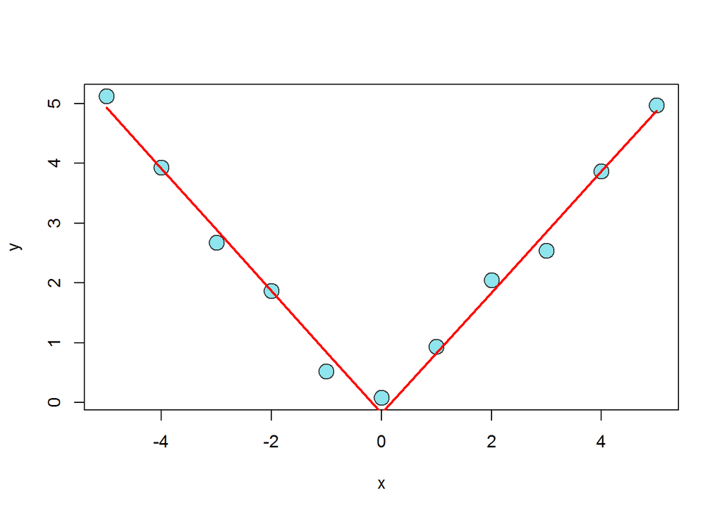

```r
x <- -5:5
y <- c(5.12, 3.93, 2.67, 1.87, 0.52, 0.08, 0.93, 2.05, 2.54, 3.87, 4.97)

plot(x, y, pch = 21,  cex = 2, col="grey20", bg="cadetblue2")

knots <- 0
splineTerms <- sapply(knots, function(knot) (x > knot) * (x - knot))
xmat <- cbind(1, x, splineTerms)
mdl6 <- lm(y~xmat-1)
yhat<-predict(mdl6)
lines(x, yhat, col = "red", lwd = 2)
```

```r
summary(mdl6)
```

```
##
## Call:
## lm(formula = y ~ xmat - 1)
##
## Residuals:
##     Min      1Q  Median      3Q     Max
## -0.3216 -0.1098  0.0159  0.1407  0.2626
##
## Coefficients:
##       Estimate Std. Error t value Pr(>|t|)
## xmat   -0.1826     0.1356   -1.35     0.21
## xmatx  -1.0242     0.0481  -21.31  2.5e-08 ***
## xmat    2.0372     0.0857   23.76  1.0e-08 ***
## ---
## Signif. codes:  0 '***' 0.001 '**' 0.01 '*' 0.05 '.' 0.1 ' ' 1
##
## Residual standard error: 0.228 on 8 degrees of freedom
## Multiple R-squared:  0.996,  Adjusted R-squared:  0.995
## F-statistic:  665 on 3 and 8 DF,  p-value: 6.25e-10
```

```r
sum(coef(mdl6)[2:3])
```

```
## [1] 1.01
```

#### Answer 6:

The slope of the line after 0 is 1.013.